신록예찬's 블로그

# (노트) employee data 시각화

Nov 1, 2021 • 최규빈 • 12 min read

시각화

- import
- 자료소개
- 자료정리
- 분석1: 급여의 평균, 최소값, 최대값을 비교
  - 그룹핑
  - 시각화1 (bar plot)
  - 시각화2
- 분석2: 박스플랏비교
- 분석3: 그룹별로 샘플수를 고려하자.
  - 그림의 첫번째 수정
  - 그림의 두번째 수정
  - 그림 에러의 근본적 원인
  - 그림의 세번째 수정

### import

```python
import pandas as pd
import numpy as np
from plotnine import *
```

### 자료소개

```python
df=pd.read_csv('https://raw.githubusercontent.com/PacktPublishing/Pandas-Cookbook/master/data/employee.csv')
df
```

|  | UNIQUE_ID | POSITION_TITLE | DEPARTMENT | BASE_SALARY | RACE | EMPLOYMENT_TYPE | GENDER | EMPLOYMENT_STATUS | HIRE_DATE | JOB_DATE |
| --- | --- | --- | --- | --- | --- | --- | --- | --- | --- | --- |
| 0 | 0 | ASSISTANT DIRECTOR (EX LVL) | Municipal Courts Department | 121862.0 | Hispanic/Latino | Full Time | Female | Active | 2006-06-12 | 2012-10-13 |
| 1 | 1 | LIBRARY ASSISTANT | Library | 26125.0 | Hispanic/Latino | Full Time | Female | Active | 2000-07-19 | 2010-09-18 |
| 2 | 2 | POLICE OFFICER | Houston Police Department-HPD | 45279.0 | White | Full Time | Male | Active | 2015-02-03 | 2015-02-03 |
| 3 | 3 | ENGINEER/OPERATOR | Houston Fire Department (HFD) | 63166.0 | White | Full Time | Male | Active | 1982-02-08 | 1991-05-25 |
| 4 | 4 | ELECTRICIAN | General Services Department | 56347.0 | White | Full Time | Male | Active | 1989-06-19 | 1994-10-22 |
| ... | ... | ... | ... | ... | ... | ... | ... | ... | ... | ... |
| 1995 | 1995 | POLICE OFFICER | Houston Police Department-HPD | 43443.0 | White | Full Time | Male | Active | 2014-06-09 | 2015-06-09 |
| 1996 | 1996 | COMMUNICATIONS CAPTAIN | Houston Fire Department (HFD) | 66523.0 | Black or African American | Full Time | Male | Active | 2003-09-02 | 2013-10-06 |
| 1997 | 1997 | POLICE OFFICER | Houston Police Department-HPD | 43443.0 | White | Full Time | Male | Active | 2014-10-13 | 2015-10-13 |
| 1998 | 1998 | POLICE OFFICER | Houston Police Department-HPD | 55461.0 | Asian/Pacific Islander | Full Time | Male | Active | 2009-01-20 | 2011-07-02 |
| 1999 | 1999 | FIRE FIGHTER | Houston Fire Department (HFD) | 51194.0 | Hispanic/Latino | Full Time | Male | Active | 2009-01-12 | 2010-07-12 |

2000 rows × 10 columns

`-` 목표: 인종별, 성별로 차별이 있는지?

### 자료정리

`-` 결측치제거

```python
df.dropna()
```

|  | UNIQUE_ID | POSITION_TITLE | DEPARTMENT | BASE_SALARY | RACE | EMPLOYMENT_TYPE | GENDER | EMPLOYMENT_STATUS | HIRE_DATE | JOB_DATE |
| --- | --- | --- | --- | --- | --- | --- | --- | --- | --- | --- |
| 0 | 0 | ASSISTANT DIRECTOR (EX LVL) | Municipal Courts Department | 121862.0 | Hispanic/Latino | Full Time | Female | Active | 2006-06-12 | 2012-10-13 |
| 1 | 1 | LIBRARY ASSISTANT | Library | 26125.0 | Hispanic/Latino | Full Time | Female | Active | 2000-07-19 | 2010-09-18 |
| 2 | 2 | POLICE OFFICER | Houston Police Department-HPD | 45279.0 | White | Full Time | Male | Active | 2015-02-03 | 2015-02-03 |
| 3 | 3 | ENGINEER/OPERATOR | Houston Fire Department (HFD) | 63166.0 | White | Full Time | Male | Active | 1982-02-08 | 1991-05-25 |
| 4 | 4 | ELECTRICIAN | General Services Department | 56347.0 | White | Full Time | Male | Active | 1989-06-19 | 1994-10-22 |
| ... | ... | ... | ... | ... | ... | ... | ... | ... | ... | ... |
| 1995 | 1995 | POLICE OFFICER | Houston Police Department-HPD | 43443.0 | White | Full Time | Male | Active | 2014-06-09 | 2015-06-09 |
| 1996 | 1996 | COMMUNICATIONS CAPTAIN | Houston Fire Department (HFD) | 66523.0 | Black or African American | Full Time | Male | Active | 2003-09-02 | 2013-10-06 |
| 1997 | 1997 | POLICE OFFICER | Houston Police Department-HPD | 43443.0 | White | Full Time | Male | Active | 2014-10-13 | 2015-10-13 |
| 1998 | 1998 | POLICE OFFICER | Houston Police Department-HPD | 55461.0 | Asian/Pacific Islander | Full Time | Male | Active | 2009-01-20 | 2011-07-02 |
| 1999 | 1999 | FIRE FIGHTER | Houston Fire Department (HFD) | 51194.0 | Hispanic/Latino | Full Time | Male | Active | 2009-01-12 | 2010-07-12 |

1853 rows × 10 columns

```python
df=df.dropna()
```

- 결측치를 처리

### 분석1: 급여의 평균, 최소값, 최대값을 비교

#### 그룹핑

```python
df.groupby(['RACE','GENDER']).agg({'BASE_SALARY': [np.mean,np.max,np.min]}).reset_index()
```

|  | RACE | GENDER | BASE_SALARY mean | BASE_SALARY amax | BASE_SALARY amin |
| --- | --- | --- | --- | --- | --- |
| 0 | American Indian or Alaskan Native | Female | 60238.800000 | 98536.0 | 26125.0 |
| 1 | American Indian or Alaskan Native | Male | 60305.400000 | 81239.0 | 26125.0 |
| 2 | Asian/Pacific Islander | Female | 63226.300000 | 130416.0 | 26125.0 |
| 3 | Asian/Pacific Islander | Male | 61033.906667 | 163228.0 | 27914.0 |
| 4 | Black or African American | Female | 48965.790378 | 150416.0 | 24960.0 |
| 5 | Black or African American | Male | 51118.867374 | 275000.0 | 26125.0 |
| 6 | Hispanic/Latino | Female | 46503.316176 | 126115.0 | 26125.0 |
| 7 | Hispanic/Latino | Male | 54767.541538 | 165216.0 | 26104.0 |
| 8 | Others | Female | 63785.000000 | 63785.0 | 63785.0 |
| 9 | Others | Male | 38771.000000 | 38771.0 | 38771.0 |
| 10 | White | Female | 66793.352941 | 178331.0 | 27955.0 |
| 11 | White | Male | 63940.388119 | 210588.0 | 26125.0 |

```python
df.groupby(['RACE','GENDER']).agg({'BASE_SALARY': [np.mean,np.max,np.min]}).reset_index().columns
```

```
MultiIndex([(       'RACE',     ''),
            (     'GENDER',     ''),
            ('BASE_SALARY', 'mean'),
            ('BASE_SALARY', 'amax'),
            ('BASE_SALARY', 'amin')],
           )
```

```python
df.groupby(['RACE','GENDER']).agg({'BASE_SALARY': [np.mean,np.max,np.min]})\
.reset_index()\
.rename(columns={'amax':'max','amin':'min'})
```

|  | RACE | GENDER | BASE_SALARY mean | BASE_SALARY max | BASE_SALARY min |
| --- | --- | --- | --- | --- | --- |
| 0 | American Indian or Alaskan Native | Female | 60238.800000 | 98536.0 | 26125.0 |
| 1 | American Indian or Alaskan Native | Male | 60305.400000 | 81239.0 | 26125.0 |
| 2 | Asian/Pacific Islander | Female | 63226.300000 | 130416.0 | 26125.0 |
| 3 | Asian/Pacific Islander | Male | 61033.906667 | 163228.0 | 27914.0 |
| 4 | Black or African American | Female | 48965.790378 | 150416.0 | 24960.0 |
| 5 | Black or African American | Male | 51118.867374 | 275000.0 | 26125.0 |
| 6 | Hispanic/Latino | Female | 46503.316176 | 126115.0 | 26125.0 |
| 7 | Hispanic/Latino | Male | 54767.541538 | 165216.0 | 26104.0 |
| 8 | Others | Female | 63785.000000 | 63785.0 | 63785.0 |
| 9 | Others | Male | 38771.000000 | 38771.0 | 38771.0 |
| 10 | White | Female | 66793.352941 | 178331.0 | 27955.0 |
| 11 | White | Male | 63940.388119 | 210588.0 | 26125.0 |

```python
df.groupby(['RACE','GENDER']).agg({'BASE_SALARY': [np.mean,np.max,np.min]})\
.reset_index()\
.rename(columns={'amax':'max','amin':'min'})\
.melt(id_vars=['RACE','GENDER'])\
.rename(columns={'variable_1':'aggtype'})
```

|  | RACE | GENDER | variable_0 | aggtype | value |
| --- | --- | --- | --- | --- | --- |
| 0 | American Indian or Alaskan Native | Female | BASE_SALARY | mean | 60238.800000 |
| 1 | American Indian or Alaskan Native | Male | BASE_SALARY | mean | 60305.400000 |
| 2 | Asian/Pacific Islander | Female | BASE_SALARY | mean | 63226.300000 |
| 3 | Asian/Pacific Islander | Male | BASE_SALARY | mean | 61033.906667 |
| 4 | Black or African American | Female | BASE_SALARY | mean | 48965.790378 |
| 5 | Black or African American | Male | BASE_SALARY | mean | 51118.867374 |
| 6 | Hispanic/Latino | Female | BASE_SALARY | mean | 46503.316176 |
| 7 | Hispanic/Latino | Male | BASE_SALARY | mean | 54767.541538 |
| 8 | Others | Female | BASE_SALARY | mean | 63785.000000 |
| 9 | Others | Male | BASE_SALARY | mean | 38771.000000 |
| 10 | White | Female | BASE_SALARY | mean | 66793.352941 |
| 11 | White | Male | BASE_SALARY | mean | 63940.388119 |
| 12 | American Indian or Alaskan Native | Female | BASE_SALARY | max | 98536.000000 |
| 13 | American Indian or Alaskan Native | Male | BASE_SALARY | max | 81239.000000 |
| 14 | Asian/Pacific Islander | Female | BASE_SALARY | max | 130416.000000 |
| 15 | Asian/Pacific Islander | Male | BASE_SALARY | max | 163228.000000 |
| 16 | Black or African American | Female | BASE_SALARY | max | 150416.000000 |
| 17 | Black or African American | Male | BASE_SALARY | max | 275000.000000 |
| 18 | Hispanic/Latino | Female | BASE_SALARY | max | 126115.000000 |
| 19 | Hispanic/Latino | Male | BASE_SALARY | max | 165216.000000 |
| 20 | Others | Female | BASE_SALARY | max | 63785.000000 |
| 21 | Others | Male | BASE_SALARY | max | 38771.000000 |
| 22 | White | Female | BASE_SALARY | max | 178331.000000 |
| 23 | White | Male | BASE_SALARY | max | 210588.000000 |
| 24 | American Indian or Alaskan Native | Female | BASE_SALARY | min | 26125.000000 |
| 25 | American Indian or Alaskan Native | Male | BASE_SALARY | min | 26125.000000 |
| 26 | Asian/Pacific Islander | Female | BASE_SALARY | min | 26125.000000 |
| 27 | Asian/Pacific Islander | Male | BASE_SALARY | min | 27914.000000 |
| 28 | Black or African American | Female | BASE_SALARY | min | 24960.000000 |
| 29 | Black or African American | Male | BASE_SALARY | min | 26125.000000 |
| 30 | Hispanic/Latino | Female | BASE_SALARY | min | 26125.000000 |
| 31 | Hispanic/Latino | Male | BASE_SALARY | min | 26104.000000 |
| 32 | Others | Female | BASE_SALARY | min | 63785.000000 |
| 33 | Others | Male | BASE_SALARY | min | 38771.000000 |
| 34 | White | Female | BASE_SALARY | min | 27955.000000 |
| 35 | White | Male | BASE_SALARY | min | 26125.000000 |

```python
tidy=df.groupby(['RACE','GENDER']).agg({'BASE_SALARY': [np.mean,np.max,np.min]})\
.reset_index()\
.rename(columns={'amax':'max','amin':'min'})\
.melt(id_vars=['RACE','GENDER'])\
.rename(columns={'variable_1':'aggtype'})
```

```python
tidy.head()
```

|  | RACE | GENDER | variable_0 | aggtype | value |
| --- | --- | --- | --- | --- | --- |
| 0 | American Indian or Alaskan Native | Female | BASE_SALARY | mean | 60238.800000 |
| 1 | American Indian or Alaskan Native | Male | BASE_SALARY | mean | 60305.400000 |
| 2 | Asian/Pacific Islander | Female | BASE_SALARY | mean | 63226.300000 |
| 3 | Asian/Pacific Islander | Male | BASE_SALARY | mean | 61033.906667 |
| 4 | Black or African American | Female | BASE_SALARY | mean | 48965.790378 |

#### 시각화1 (bar plot)

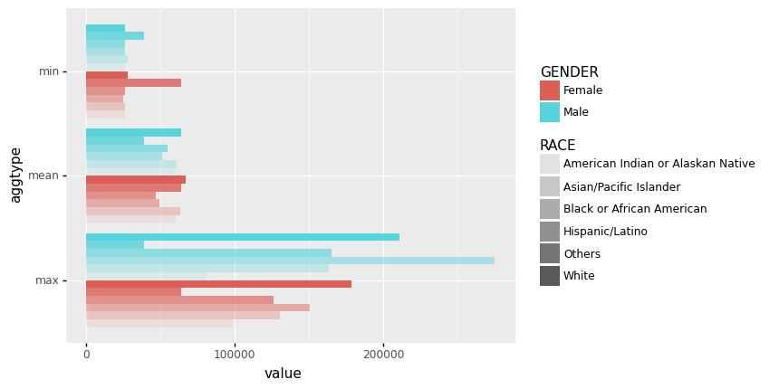

```python
fig=ggplot(tidy)
bar1=geom_bar(aes(x='aggtype',y='value',fill='GENDER',alpha='RACE'),stat='identity',position='dodge')
fig+bar1+coord_flip()
```

- 해들리위컴: 모든 그래프는 데이터 + 지옴 + 맵핑(변수와 에스테틱간의 맵핑) + 스탯(통계) + 포지션 + 축 + 패싯그리드 7개의 조합으로 만들 수 있다.

#### 시각화2

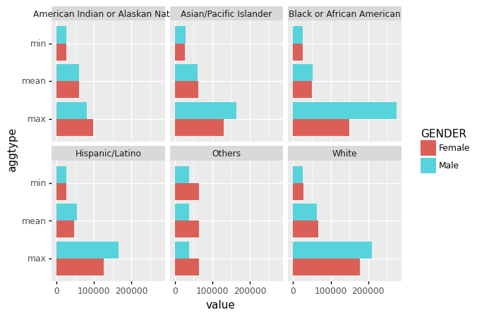

```python
bar2=geom_bar(aes(x='aggtype',y='value',fill='GENDER'),stat='identity',position='dodge')
fig+bar2+coord_flip()+facet_wrap(facets="RACE")
```

`-` 해석

- max만 놓고보면 Black/Male 의 연봉이 가장 높다.
- 하지만 전체적으로 흑인의 대우가 좋다고 볼 수 없다.
- 인종별로도 차이가 있어보이지만 뚜렷하지 않음.
- min,mean,max 3가지 값으로만 파악하려니 조금 답답하다..

### 분석2: 박스플랏비교

`-` 원래의 자료로 다시 그림을 그려보자.

```python
fig2=ggplot(df)
```

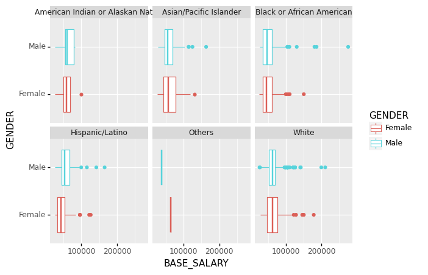

```python
fig2+geom_boxplot(aes(x='GENDER',y='BASE_SALARY',color='GENDER'))+facet_wrap('~RACE')+coord_flip()
```

`-` Others 에서는 오히려 여성의 급여가 높다. $\to$ 반박: 여기는 샘플수가 별로없다

### 분석3: 그룹별로 샘플수를 고려하자.

```python
df.groupby(['RACE','GENDER']).agg({'BASE_SALARY':'count'}).reset_index()
```

|  | RACE | GENDER | BASE_SALARY |
| --- | --- | --- | --- |
| 0 | American Indian or Alaskan Native | Female | 5 |
| 1 | American Indian or Alaskan Native | Male | 5 |
| 2 | Asian/Pacific Islander | Female | 30 |
| 3 | Asian/Pacific Islander | Male | 75 |
| 4 | Black or African American | Female | 291 |
| 5 | Black or African American | Male | 377 |
| 6 | Hispanic/Latino | Female | 136 |
| 7 | Hispanic/Latino | Male | 325 |
| 8 | Others | Female | 1 |
| 9 | Others | Male | 1 |
| 10 | White | Female | 102 |
| 11 | White | Male | 505 |

```python
df.groupby(['RACE','GENDER']).agg({'BASE_SALARY':'count'}).reset_index().rename(columns={'BASE_SALARY':'COUNT'})
```

|  | RACE | GENDER | COUNT |
| --- | --- | --- | --- |
| 0 | American Indian or Alaskan Native | Female | 5 |
| 1 | American Indian or Alaskan Native | Male | 5 |
| 2 | Asian/Pacific Islander | Female | 30 |
| 3 | Asian/Pacific Islander | Male | 75 |
| 4 | Black or African American | Female | 291 |
| 5 | Black or African American | Male | 377 |
| 6 | Hispanic/Latino | Female | 136 |
| 7 | Hispanic/Latino | Male | 325 |
| 8 | Others | Female | 1 |
| 9 | Others | Male | 1 |
| 10 | White | Female | 102 |
| 11 | White | Male | 505 |

- 카운트가 10이하인것을 고려할 필요가 있나?

```python
tb=df.groupby(['RACE','GENDER']).agg({'BASE_SALARY':'count'}).reset_index().rename(columns={'BASE_SALARY':'COUNT'}).merge(df)
tb
```

|  | RACE | GENDER | COUNT | UNIQUE_ID | POSITION_TITLE | DEPARTMENT | BASE_SALARY | EMPLOYMENT_TYPE | EMPLOYMENT_STATUS | HIRE_DATE | JOB_DATE |
| --- | --- | --- | --- | --- | --- | --- | --- | --- | --- | --- | --- |
| 0 | American Indian or Alaskan Native | Female | 5 | 396 | PUBLIC INFORMATION OFFICER (EXECUTIVE LE | Housing and Community Devp. | 98536.0 | Full Time | Active | 2014-01-27 | 2014-01-27 |
| 1 | American Indian or Alaskan Native | Female | 5 | 1040 | COMMUNITY LIAISON | Health & Human Services | 49379.0 | Full Time | Active | 2003-11-05 | 2006-11-18 |
| 2 | American Indian or Alaskan Native | Female | 5 | 1593 | SYSTEMS SUPPORT ANALYST III | Houston Airport System (HAS) | 68299.0 | Full Time | Active | 1995-11-20 | 2007-09-22 |
| 3 | American Indian or Alaskan Native | Female | 5 | 1846 | LIBRARY ASSISTANT | Library | 26125.0 | Full Time | Active | 2008-05-05 | 2013-01-19 |
| 4 | American Indian or Alaskan Native | Female | 5 | 1905 | NUTRITIONIST CONSULTANT | Health & Human Services | 58855.0 | Full Time | Active | 1999-09-07 | 2006-08-19 |
| ... | ... | ... | ... | ... | ... | ... | ... | ... | ... | ... | ... |
| 1848 | White | Male | 505 | 1986 | POLICE SERGEANT | Houston Police Department-HPD | 77076.0 | Full Time | Active | 2001-12-03 | 2010-12-10 |
| 1849 | White | Male | 505 | 1988 | SENIOR ASSISTANT CITY ATTORNEY II | Legal Department | 124115.0 | Full Time | Active | 2013-01-23 | 2013-03-02 |
| 1850 | White | Male | 505 | 1993 | POLICE SERGEANT | Houston Police Department-HPD | 81239.0 | Full Time | Active | 1982-05-03 | 2011-09-03 |
| 1851 | White | Male | 505 | 1995 | POLICE OFFICER | Houston Police Department-HPD | 43443.0 | Full Time | Active | 2014-06-09 | 2015-06-09 |
| 1852 | White | Male | 505 | 1997 | POLICE OFFICER | Houston Police Department-HPD | 43443.0 | Full Time | Active | 2014-10-13 | 2015-10-13 |

1853 rows × 11 columns

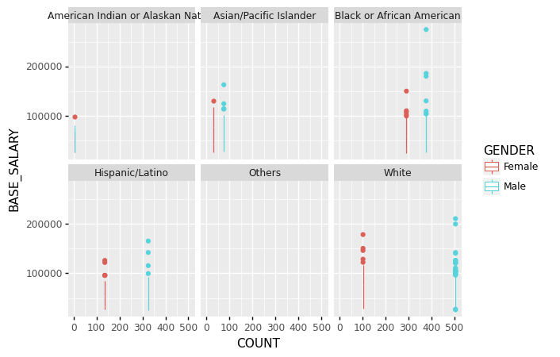

```python
fig3=ggplot(tb)
fig3+geom_boxplot(aes(x='COUNT',y='BASE_SALARY',color='GENDER'))+facet_wrap('RACE')
```

`-` 그림이 좀 이상하다..

#### 그림의 첫번째 수정

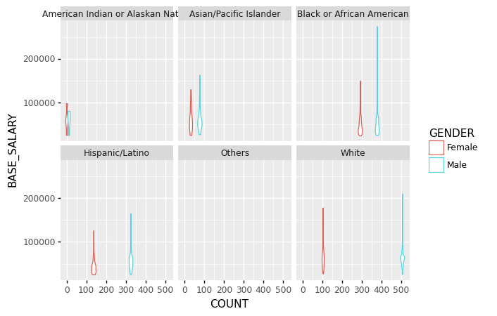

```python
fig3+geom_violin(aes(x='COUNT',y='BASE_SALARY',color='GENDER'))+facet_wrap('RACE')
```

#### 그림의 두번째 수정

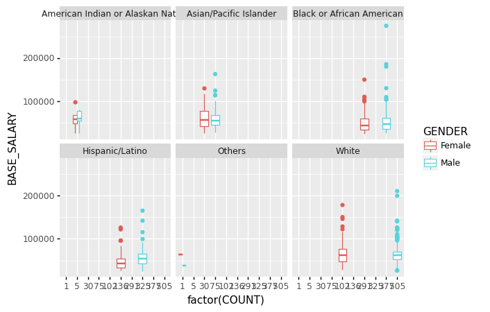

```python
fig3+geom_boxplot(aes(x='factor(COUNT)',y='BASE_SALARY',color='GENDER'))+facet_wrap('RACE')
```

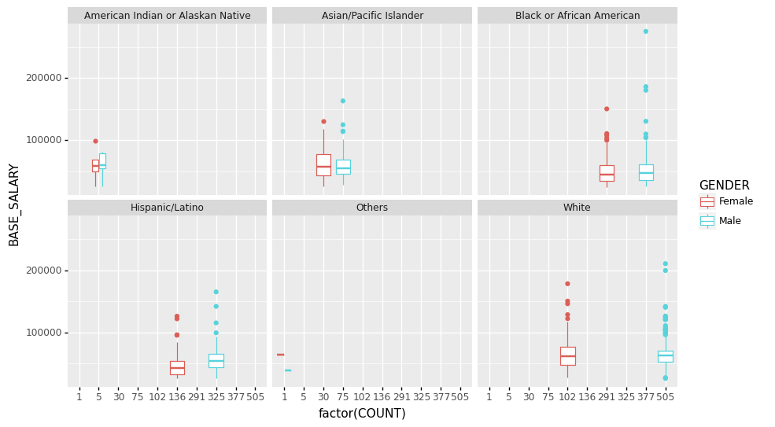

```python
fig3+geom_boxplot(aes(x='factor(COUNT)',y='BASE_SALARY',color='GENDER'))+facet_wrap('RACE')+theme(figure_size=(10,6))
```

- 한결보기 편해졌는데, 그래도 x축이 범주형처럼 들어가 있어서 아쉽다.

#### 그림 에러의 근본적 원인

`-` plotnine이 아니라 ggplot 자체의 문제임

```python
_x=[100]*100+[101]*150+[110]*150
_y=np.random.normal(loc=0,scale=1,size=400)
_g=['F']*100+['M']*300
```

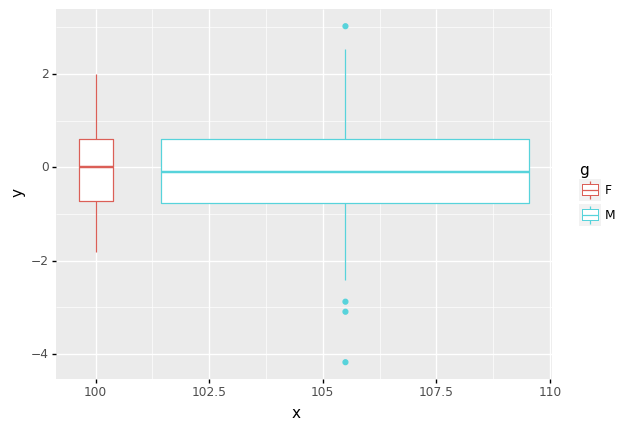

```python
ggplot(pd.DataFrame({'x':_x,'y':_y,'g':_g}))+geom_boxplot(aes(x='x',y='y',color='g'))
```

`-` 박스플랏의 width는 고정값이 아니라 추정된 값임 (x축의 변화폭 + 박스플랏간 간격등을 적절히 고려)

#### 그림의 세번째 수정

```python
tb['COUNT2']=list(map(lambda x: x+np.random.randn()*10,tb.COUNT))
```

```python
tb
```

|  | RACE | GENDER | COUNT | UNIQUE_ID | POSITION_TITLE | DEPARTMENT | BASE_SALARY | EMPLOYMENT_TYPE | EMPLOYMENT_STATUS | HIRE_DATE | JOB_DATE | COUNT2 |
| --- | --- | --- | --- | --- | --- | --- | --- | --- | --- | --- | --- | --- |
| 0 | American Indian or Alaskan Native | Female | 5 | 396 | PUBLIC INFORMATION OFFICER (EXECUTIVE LE | Housing and Community Devp. | 98536.0 | Full Time | Active | 2014-01-27 | 2014-01-27 | -12.672611 |
| 1 | American Indian or Alaskan Native | Female | 5 | 1040 | COMMUNITY LIAISON | Health & Human Services | 49379.0 | Full Time | Active | 2003-11-05 | 2006-11-18 | -0.437553 |
| 2 | American Indian or Alaskan Native | Female | 5 | 1593 | SYSTEMS SUPPORT ANALYST III | Houston Airport System (HAS) | 68299.0 | Full Time | Active | 1995-11-20 | 2007-09-22 | 5.413602 |
| 3 | American Indian or Alaskan Native | Female | 5 | 1846 | LIBRARY ASSISTANT | Library | 26125.0 | Full Time | Active | 2008-05-05 | 2013-01-19 | -10.453069 |
| 4 | American Indian or Alaskan Native | Female | 5 | 1905 | NUTRITIONIST CONSULTANT | Health & Human Services | 58855.0 | Full Time | Active | 1999-09-07 | 2006-08-19 | 7.707637 |
| ... | ... | ... | ... | ... | ... | ... | ... | ... | ... | ... | ... | ... |
| 1848 | White | Male | 505 | 1986 | POLICE SERGEANT | Houston Police Department-HPD | 77076.0 | Full Time | Active | 2001-12-03 | 2010-12-10 | 489.851351 |
| 1849 | White | Male | 505 | 1988 | SENIOR ASSISTANT CITY ATTORNEY II | Legal Department | 124115.0 | Full Time | Active | 2013-01-23 | 2013-03-02 | 511.074323 |
| 1850 | White | Male | 505 | 1993 | POLICE SERGEANT | Houston Police Department-HPD | 81239.0 | Full Time | Active | 1982-05-03 | 2011-09-03 | 499.708646 |
| 1851 | White | Male | 505 | 1995 | POLICE OFFICER | Houston Police Department-HPD | 43443.0 | Full Time | Active | 2014-06-09 | 2015-06-09 | 486.638328 |
| 1852 | White | Male | 505 | 1997 | POLICE OFFICER | Houston Police Department-HPD | 43443.0 | Full Time | Active | 2014-10-13 | 2015-10-13 | 492.137469 |

1853 rows × 12 columns

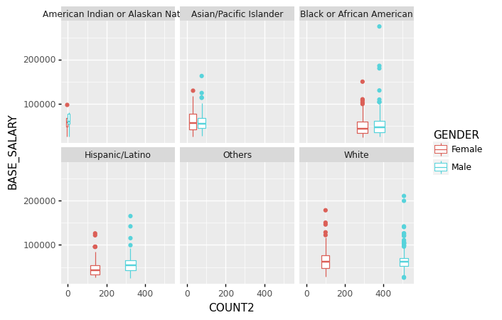

```python
fig4=ggplot(tb)
fig4+geom_boxplot(aes(x='COUNT2',y='BASE_SALARY',color='GENDER'))+facet_wrap('RACE')
```

- 다 좋은데 아웃라이어가 너무 크게보인다.

```python
geom_boxplot?
```

```
Init signature: geom_boxplot(mapping=None, data=None, **kwargs)
Docstring:
Box and whiskers plot


.. rubric:: Usage

::

    geom_boxplot(mapping=None, data=None, stat='boxplot', position='dodge2',
                 na_rm=False, inherit_aes=True, show_legend=None, raster=False,
                 notch=False, outlier_color=None, outlier_alpha=1,
                 outlier_size=1.5, fatten=2, varwidth=False, outlier_shape='o',
                 outlier_stroke=0.5, width=None, notchwidth=0.5, **kwargs)

Only the ``mapping`` and ``data`` can be positional, the rest must
be keyword arguments. ``**kwargs`` can be aesthetics (or parameters)
used by the ``stat``.


Parameters
----------
mapping : aes, optional
    Aesthetic mappings created with :meth:`~plotnine.aes`. If specified and :py:`inherit.aes=True`, it is combined with the default mapping for the plot. You must supply mapping if there is no plot mapping.

    ========== ==========
    Aesthetic  Default value
    ========== ==========
    **lower**
    **middle**
    **upper**
    **x**
    **ymax**
    **ymin**
    alpha      :py:`1`
    color      :py:`'#333333'`
    fill       :py:`'white'`
    group
    linetype   :py:`'solid'`
    shape      :py:`'o'`
```

[output cut: 34 more lines]

```
    Stroke-size of the outlier points.
notch : bool, optional (default: False)
    Whether the boxes should have a notch.
varwidth : bool, optional (default: False)
    If :py:`True`, boxes are drawn with widths proportional to
    the square-roots of the number of observations in the
    groups.
notchwidth : float, optional (default: 0.5)
    Width of notch relative to the body width.
fatten : float, optional (default: 2)
    A multiplicative factor used to increase the size of the
    middle bar across the box.
File:           ~/anaconda3/envs/py38r40/lib/python3.8/site-packages/plotnine/geoms/geom_boxplot.py
Type:           Registry
Subclasses:
```

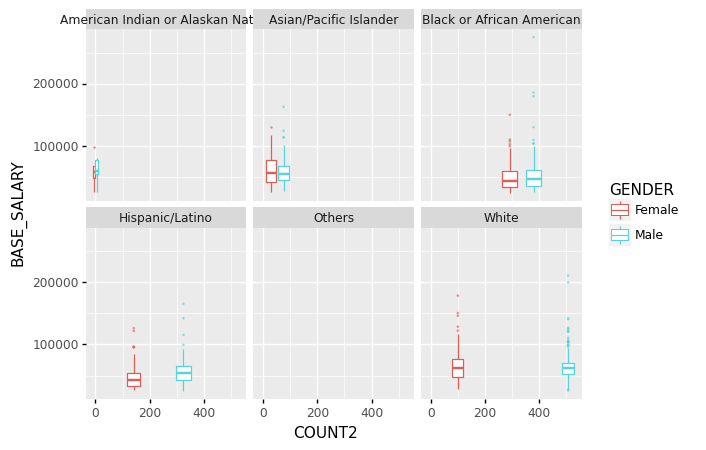

```python
fig4+geom_boxplot(aes(x='COUNT2',y='BASE_SALARY',color='GENDER'),outlier_size=0.1,outlier_alpha=0.5)+facet_wrap('RACE')
```

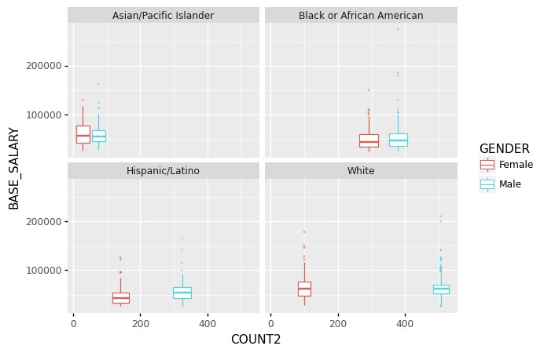

```python
ggplot(tb.query('COUNT>10'))+geom_boxplot(aes(x='COUNT2',y='BASE_SALARY',color='GENDER'),outlier_size=0.1,outlier_alpha=0.5)+facet_wrap('RACE')
```